# Practical Machine Learning Course Project Report

Yukai Zou

24 October, 2015

## Summary

Using devices to recognize human activity is one of the most cutting-edge technologies in the 21st century, attracting smart data scientists to find solutions. There are currently over a hundred machine learning packages that are available for making predictions, but which one is the best for a particular application is always debatable. In the context of human activity recognition, predicting with high accuracy yet not consuming unreasonable amount of time is the fundamental concern, as these devices need to recognize the user’s behavior quickly and respond with warnings or instruction messages, especially in monitoring elderly groups or correcting improper performance in physical exercises. To briefly demonstrating how the model is chosen, we employed linear discriminant analysis (*lda*), tree-based model (*rpart*), and random forest model (*randomForest*). Among the three models during cross validation, *randomTree* outweighed the other two in accuracy for predicting the classe on the testing set, plus do not consume much time. In the final testing, *randomForest* predicted all the 20 cases correctly.

## Data

The data used in this project is available from http://groupware.les.inf.puc-rio.br/har (see Reference). Data were acquired from accelerometers on the belt, forearm, arm, and dumbell of 6 participants. The participants were asked to lift barbell in 5 different ways, both correctly and incorrectly. There are both training and testing datasets (see Reference). In the training dataset, there are 19622 rows and 160 columns; in the testing dataset, there are 20 rows and 160 columns.

## Model Fitting and Interpretation

### Strategy

We first began with cleaning the training dataset through some exploratory analysis. After removing the useless variables, the training dataset was splitted into subsets of training and testing data. Three models were fitted using the subset of training data, and cross validations were performed using the subset of testing data. Accuracy, out of sample error, and elapsed time for each model were measured during cross validations. Based on the overall performance in accuracy and the elapsed time, the best model was chosen for predicting the 20 cases in the testing dataset.

### Results of Model Fitting

- **lda**

```
##   parameter  Accuracy     Kappa  AccuracySD     KappaSD
## 1      none 0.8066089 0.7552293 0.004907386 0.006157083
```

- **rpart**

```
##           cp  Accuracy      Kappa AccuracySD    KappaSD
## 1 0.04976135 0.4481733 0.27145311 0.07152496 0.12067275
## 2 0.05053993 0.4257286 0.23394278 0.06277885 0.10984685
## 3 0.11465421 0.3252723 0.06307032 0.03972042 0.06189164
```

```
## n= 13738
##
## node), split, n, loss, yval, (yprob)
##       * denotes terminal node
##
##  1) root 13738 9847 A (0.28 0.19 0.18 0.16 0.18)
##    2) roll_belt< 130.5 12589 8708 A (0.31 0.21 0.19 0.18 0.11)
##      4) pitch_forearm< -33.95 1122    4 A (1 0.0036 0 0 0) *
##      5) pitch_forearm>=-33.95 11467 8704 A (0.24 0.23 0.21 0.2 0.12)
##       10) cvtd_timestamp< 2.5 1033  237 A (0.77 0.23 0 0 0) *
##       11) cvtd_timestamp>=2.5 10434 8008 C (0.19 0.23 0.23 0.22 0.13)
##         22) magnet_dumbbell_z< -24.5 3919 2514 A (0.36 0.29 0.095 0.21 0.053) *
##         23) magnet_dumbbell_z>=-24.5 6515 4460 C (0.086 0.2 0.32 0.22 0.18) *
##    3) roll_belt>=130.5 1149   10 E (0.0087 0 0 0 0.99) *
```

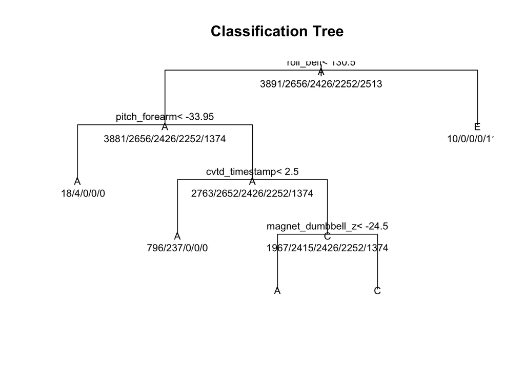

- **randomForest**

```
##
## Call:
##  randomForest(formula = classe ~ ., data = training.train[, -c(1,      2)])
##                Type of random forest: classification
##                      Number of trees: 500
## No. of variables tried at each split: 7
##
##         OOB estimate of  error rate: 0.09%
## Confusion matrix:
##      A    B    C    D    E  class.error
## A 3891    0    0    0    0 0.0000000000
## B    2 2654    0    0    0 0.0007530120
## C    0    5 2421    0    0 0.0020610058
## D    0    0    3 2248    1 0.0017761989
## E    0    0    0    1 2512 0.0003979308
```

Among the three methods, *randomForest* had a very low OOB estimate of error rate (0.09%), whereas *rpart* had a very low performance in terms of accuracy (less than 50%).

**Elapsed time of fitting three models:**

```
##                       lda  rpart randomForest
## elapsed time (sec) 15.244 61.118       48.586
```

### Result of Cross Validations

- **lda**

```
## Confusion Matrix and Statistics
##
##           Reference
## Prediction    A    B    C    D    E
##          A 1562   60   43   24    0
##          B  165  755  165   30   26
##          C   34   85  769  100    8
##          D    6   20  116  777   45
##          E    3   29   40  148  874
##
## Overall Statistics
##
##                Accuracy : 0.8051
##                  95% CI : (0.7947, 0.8151)
##     No Information Rate : 0.3008
##     P-Value [Acc > NIR] : < 2.2e-16
##
##                   Kappa : 0.7531
##  Mcnemar's Test P-Value : < 2.2e-16
##
## Statistics by Class:
##
##                      Class: A Class: B Class: C Class: D Class: E
## Sensitivity            0.8825   0.7956   0.6787   0.7201   0.9171
## Specificity            0.9691   0.9218   0.9522   0.9611   0.9554
## Pos Pred Value         0.9248   0.6617   0.7721   0.8060   0.7989
## Neg Pred Value         0.9504   0.9591   0.9255   0.9386   0.9835
## Prevalence             0.3008   0.1613   0.1926   0.1834   0.1620
## Detection Rate         0.2655   0.1283   0.1307   0.1321   0.1485
## Detection Prevalence   0.2870   0.1939   0.1693   0.1638   0.1859
## Balanced Accuracy      0.9258   0.8587   0.8155   0.8406   0.9362
```

- **rpart**

```
## Confusion Matrix and Statistics
##
##           Reference
## Prediction    A    B    C    D    E
##          A 1445    0  240    0    4
##          B  563    0  578    0    0
##          C  148    0  848    0    0
##          D  306    0  658    0    0
##          E   80    0  522    0  492
##
## Overall Statistics
##
##                Accuracy : 0.4733
##                  95% CI : (0.4605, 0.4862)
##     No Information Rate : 0.4837
##     P-Value [Acc > NIR] : 0.9457
##
##                   Kappa : 0.3234
##  Mcnemar's Test P-Value : NA
##
## Statistics by Class:
##
##                      Class: A Class: B Class: C Class: D Class: E
## Sensitivity            0.5685       NA   0.2980       NA  0.99194
## Specificity            0.9270   0.8061   0.9513   0.8362  0.88827
## Pos Pred Value         0.8555       NA   0.8514       NA  0.44973
## Neg Pred Value         0.7385       NA   0.5912       NA  0.99916
## Prevalence             0.4320   0.0000   0.4837   0.0000  0.08430
## Detection Rate         0.2456   0.0000   0.1441   0.0000  0.08362
## Detection Prevalence   0.2870   0.1939   0.1693   0.1638  0.18593
## Balanced Accuracy      0.7477       NA   0.6246       NA  0.94010
```

- **randomForest**

```
## Confusion Matrix and Statistics
##
##           Reference
## Prediction    A    B    C    D    E
##          A 1689    0    0    0    0
##          B    0 1141    0    0    0
##          C    0    1  995    0    0
##          D    0    0    0  964    0
##          E    0    0    0    3 1091
##
## Overall Statistics
##
##                Accuracy : 0.9993
##                  95% CI : (0.9983, 0.9998)
##     No Information Rate : 0.287
##     P-Value [Acc > NIR] : < 2.2e-16
##
##                   Kappa : 0.9991
##  Mcnemar's Test P-Value : NA
##
## Statistics by Class:
##
##                      Class: A Class: B Class: C Class: D Class: E
## Sensitivity             1.000   0.9991   1.0000   0.9969   1.0000
## Specificity             1.000   1.0000   0.9998   1.0000   0.9994
## Pos Pred Value          1.000   1.0000   0.9990   1.0000   0.9973
## Neg Pred Value          1.000   0.9998   1.0000   0.9994   1.0000
## Prevalence              0.287   0.1941   0.1691   0.1643   0.1854
## Detection Rate          0.287   0.1939   0.1691   0.1638   0.1854
## Detection Prevalence    0.287   0.1939   0.1693   0.1638   0.1859
## Balanced Accuracy       1.000   0.9996   0.9999   0.9984   0.9997
```

In cross validations, the model fitted through *randomForest* performed the best among the three methods, classifying most of the classe correctly with an accuracy of 99.93%; *lda* ranked the second, with an accuracy of 80.51%; *rpart* was the worst, with an accuracy of only 47.33% and did not categorized any “B” and “D” correctly, according to the confusion matrix. Given the elapsed time of each method, *randomForest* was overall the best method among the three.

### Final Results of Prediction

Using the model fitted with *randomForest*, the final results of predicting the 20 cases in the testing dataset are:

```
##  1  2  3  4  5  6  7  8  9 10 11 12 13 14 15 16 17 18 19 20
##  B  A  B  A  A  E  D  B  A  A  B  C  B  A  E  E  A  B  B  B
## Levels: A B C D E
```

## Additional Notes

The methods *lda* and *rpart* were implemented through *caret* package. All the results were produced under R version 3.2.0, x86_64_apple-darwin13.4.0 (64-bit), running under OS X 10.10.5 (Yosemite). The packages involved are: *rpart_4.1-10*, *MASS_7.3-44*, *dplyr_0.4.3*, *randomForest_4.6-12*, *caret_6.0-57*, *ggplot2_1.0.1*, *lattice_0.20-33*.

## Reference

1. Velloso, E.; Bulling, A.; Gellersen, H.; Ugulino, W.; Fuks, H. Qualitative Activity Recognition of Weight Lifting Exercises. Proceedings of 4th International Conference in Cooperation with SIGCHI (Augmented Human ’13) . Stuttgart, Germany: ACM SIGCHI, 2013. Available from: http://groupware.les.inf.puc-rio.br/har
2. Training data: https://d396qusza40orc.cloudfront.net/predmachlearn/pml-training.csv
3. Testing data: https://d396qusza40orc.cloudfront.net/predmachlearn/pml-testing.csv

## Appendix: R Codes

```r
library(caret); library(randomForest); library(dplyr)
setwd("~/Desktop/Coursera/Practical Machine Learning/PML_Project/")

# Read in data and perform data cleaning
training <- read.csv("pml-training.csv", na.strings = c("NA", "")); training.NAlist <- grep("NA", training); training <- select(training, -training.NAlist)
testing <- read.csv("pml-testing.csv", na.strings = c("NA", "")); testing.NAlist <- grep("NA", testing); testing <- select(testing, -testing.NAlist)
training[,-length(training)] <- data.frame(sapply(training[,-length(training)], as.numeric))
testing[,-length(testing)] <- data.frame(sapply(testing[,-length(testing)], as.numeric))
        write.csv(training, "pml-training_processed.csv", row.names=FALSE)
        write.csv(testing, "pml-testing_processed.csv", row.names=FALSE)

# Create subset within the training data set for cross validation
inTrain <- createDataPartition(y=training$X, p=0.7, list=FALSE)
training.train <- training[inTrain,]; write.csv(training.train, file = "pml-training_train.csv", row.names = FALSE)
training.test <- training[-inTrain,]; write.csv(training.test, file = "pml-training_test.csv", row.names = FALSE)

# Train with three methods
modFit <- train(classe ~ ., method = "lda", data = training.train[,-c(1,2)]); saveRDS(modFit, "mySavedModel001.rds")
        modFit.time <- system.time(train(classe ~ ., method = "lda", data = training.train[,-c(1,2)]))
modFit2 <- train(classe ~ ., method = "rpart", data = training.train[,-c(1,2)]); saveRDS(modFit2, "mySavedModel002.rds")
        modFit2.time <- system.time(train(classe ~ ., method = "rpart", data = training.train[,-c(1,2)]))
modFit3 <- randomForest(classe ~ ., data = training.train[,-c(1,2)]); saveRDS(modFit3, "mySavedModel003.rds")
        modFit3.time <- system.time(randomForest(classe ~ ., data = training.train[,-c(1,2)]))

mod.time <- data.frame(lda = as.matrix(modFit.time)[3], rpart = as.matrix(modFit2.time)[3],
                       randomForest = as.matrix(modFit3.time)[3], row.names = "elapsed time (sec)")
        write.table(mod.time, "3 Models_elapsed time.txt")
answers1 <- predict(modFit, training.test[,-c(1,2,length(training.test))])
answers2 <- predict(modFit2, training.test[,-c(1,2,length(training.test))])
answers3 <- predict(modFit3, training.test[,-c(1,2,length(training.test))])

# Cross Validation
confusionMatrix(training.test$classe, answers1)
confusionMatrix(training.test$classe, answers2)
confusionMatrix(training.test$classe, answers3)

# Use the whole training set to make prediction
finalMod <- randomForest(classe ~ ., data = training[,-c(1,2)]); saveRDS(finalMod, "mySavedModel_final.rds")
finalMod.predict <- predict(finalMod, newdata = testing[,-c(1,2,length(testing))])
finalMod.predict
```